# Getting started with machine learning using scikit-learn

## James Bourbeau

### Big Data Madison Meetup

April 24, 2018

### GitHub repo with materials:

https://github.com/jrbourbeau/big-data-madison-ml-sklearn

### Slides:

https://jrbourbeau.github.io/big-data-madison-ml-sklearn

### Contact:

E-mail: james@jamesbourbeau.com

GitHub: jrbourbeau

Twitter: __jrbourbeau__

LinkedIn: [jrbourbeau](https://www.linkedin.com/in/jrbourbeau/)

Source code for `plotting` Python module can be found on GitHub with the rest of the materials for this talk

```python
import plotting
import numpy as np
np.random.seed(2)
%matplotlib inline
```

## Supervised machine learning workflow

[figure not shown]

Image source: [Model evaluation, model selection, and algorithm selection in machine learning](https://sebastianraschka.com/blog/2016/model-evaluation-selection-part3.html) by Sebastian Raschka

## Outline

- What is machine learning?
  - Classical programming vs. machine learning
  - Supervised machine learning
- scikit-learn:
  - Data representation
  - Estimator API
- Example algorithm: decision tree classifier
- Model validation
  - Cross validation
  - Validation curves

# Machine learning vs. classical programming

## Classical programming

- Devise a set of rules (an algorithm) that are used to accomplish a task
- For example, labeling e-mails as either "spam" or "not spam"

```python
def spam_filter(email):
    """Function that labels an email as 'spam' or 'not spam'
    """
    if 'Act now!' in email.contents:
        label = 'spam'
    elif 'hotmail.com' in email.sender:
        label = 'spam'
    elif email.contents.count('$') > 20:
        label = 'spam'
    else:
        label = 'not spam'

    return label
```

## Machine learning

- "Field of study that gives computers the ability to learn without being explicitly programmed" — Arthur Samuel (1959)
- "A machine-learning system is trained rather than explicitly programmed. It’s presented with many examples relevant to a task, and it finds statistical structure in these examples that eventually allows the system to come up with rules for automating the task." — Francois Chollet, *Deep Learning with Python*

## Supervised machine learning

- From a labeled dataset, an algorithm learns a mapping between input data and the desired output label
- Goal is to have model generalize well to future, yet unseen, data
- Supervised machine learning is further divided into two types of problems:
  - Classification — Labels are discrete. E.g. determine if a picture is of a cat, dog, or person.
  - Regression — Labels are continuous. E.g. predict home prices.

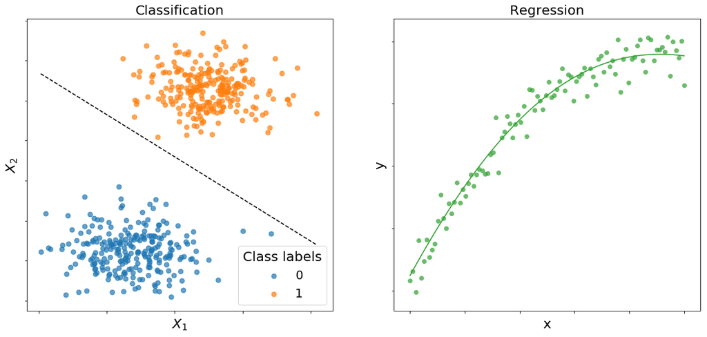

```python
plotting.plot_classification_vs_regression()
```

# Machine learning in Python with scikit-learn

## scikit-learn

- Popular Python machine learning library
- Designed to be a [well documented](http://scikit-learn.org/stable/) and approachable for non-specialist
- Built on top of NumPy and SciPy
- scikit-learn can be easily installed with `pip` or `conda`
  - `pip install scikit-learn`
  - `conda install scikit-learn`

## Data representation in scikit-learn

- Training dataset is described by a pair of matrices, one for the input data and one for the output
- Most commonly used data formats are a NumPy `ndarray` or a Pandas `DataFrame` / `Series`
- Each row of these matrices corresponds to one sample of the dataset
- Each column represents a quantitative piece of information that is used to describe each sample (called "features")

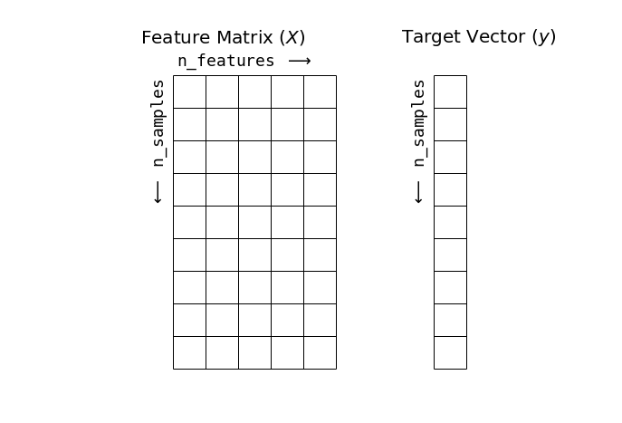

```python
plotting.plot_data_representation()
```

## Iris dataset

- Dataset consists of 150 samples (individual flowers) that have 4 features: sepal length, sepal width, petal length, and petal width (all in cm)
- Each sample is labeled by its species: Iris Setosa, Iris Versicolour, Iris Virginica
- Task is to develop a model that predicts iris species
- Iris dataset is freely available from the [UCI Machine Learning Repository](https://archive.ics.uci.edu/ml/datasets/iris)

[figure not shown]

## Loading the iris dataset

```python
import pandas as pd

iris = pd.read_csv('iris.csv')
iris = iris.sample(frac=1, random_state=2).reset_index(drop=True)
iris.head()
```

|  | sepal_length | sepal_width | petal_length | petal_width | species |
| --- | --- | --- | --- | --- | --- |
| 0 | 4.6 | 3.4 | 1.4 | 0.3 | setosa |
| 1 | 4.6 | 3.1 | 1.5 | 0.2 | setosa |
| 2 | 5.7 | 2.5 | 5.0 | 2.0 | virginica |
| 3 | 4.8 | 3.0 | 1.4 | 0.1 | setosa |
| 4 | 4.8 | 3.4 | 1.9 | 0.2 | setosa |

```python
# Only include first two training features (sepal length and sepal width)
feature_columns = ['sepal_length', 'sepal_width']
X = iris[feature_columns].values
y = iris['species'].values

print(f'First 5 samples in X: \n{X[:5]}')
print(f'First 5 labels in y: \n{y[:5]}')
```

```
First 5 samples in X:
[[4.6 3.4]
 [4.6 3.1]
 [5.7 2.5]
 [4.8 3. ]
 [4.8 3.4]]
First 5 labels in y:
['setosa' 'setosa' 'virginica' 'setosa' 'setosa']
```

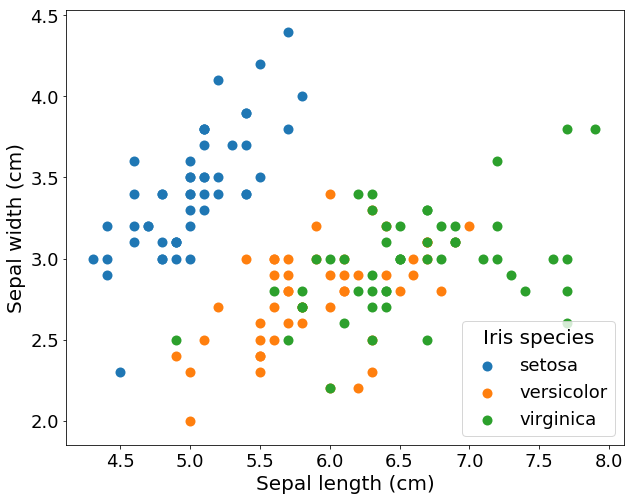

```python
plotting.plot_2D_iris()
```

## Estimators in scikit-learn

- Algorithms are implemented as estimator classes in scikit-learn
- Each estimator in scikit-learn is extensively documented (e.g. the [KNeighborsClassifier documentation](http://scikit-learn.org/stable/modules/generated/sklearn.neighbors.KNeighborsClassifier.html)) with API documentation, user guides, and example usages.

```python
from sklearn.tree import DecisionTreeClassifier, DecisionTreeRegressor
from sklearn.neighbors import KNeighborsClassifier, KNeighborsRegressor
from sklearn.ensemble import RandomForestClassifier, GradientBoostingRegressor
from sklearn.svm import SVC, SVR
from sklearn.linear_model import LinearRegression, LogisticRegression
```

- A model is an instance of one of these estimator classes

```python
model = KNeighborsClassifier(n_neighbors=5)
print(model)
```

```
KNeighborsClassifier(algorithm='auto', leaf_size=30, metric='minkowski',
           metric_params=None, n_jobs=1, n_neighbors=5, p=2,
           weights='uniform')
```

## Estimator API

```
class Estimator(BaseClass):

    def __init__(self, **hyperparameters):
        # Setup Estimator here

    def fit(self, X, y):
        # Implement algorithm here

        return self

    def predict(self, X):
        # Get predicted target from trained model
        # Note: fit must be called before predict

        return y_pred
```

See [API design for machine learning software: experiences from the scikit-learn project](https://arxiv.org/pdf/1309.0238.pdf) for a discusses of the API design choices for scikit-learn

## Training a model — fit then predict

```python
# Create the model
model = KNeighborsClassifier(n_neighbors=5)

# Fit the model
model.fit(X, y)

# Get model predictions
y_pred = model.predict(X)
y_pred[:10]
```

```
array(['setosa', 'setosa', 'versicolor', 'setosa', 'setosa', 'virginica',
       'setosa', 'versicolor', 'virginica', 'setosa'], dtype=object)
```

# Example algorithm: decision tree classifier

## Decision tree classifier

Idea behind the decision tree algorithm is to sequentially partition a training dataset by asking a series of questions.

[figure not shown]

Image source: Raschka, Sebastian, and Vahid Mirjalili. [Python Machine Learning](https://www.amazon.com/Python-Machine-Learning-scikit-learn-TensorFlow/dp/1787125939), 2nd Ed. Packt Publishing, 2017.

## Node splitting to maximize purity

[figure not shown]

## Decision tree classifier in scikit-learn

```python
from sklearn.tree import DecisionTreeClassifier

clf = DecisionTreeClassifier(max_depth=2)
clf.fit(X, y)
```

```
DecisionTreeClassifier(class_weight=None, criterion='gini', max_depth=2,
            max_features=None, max_leaf_nodes=None,
            min_impurity_decrease=0.0, min_impurity_split=None,
            min_samples_leaf=1, min_samples_split=2,
            min_weight_fraction_leaf=0.0, presort=False, random_state=None,
            splitter='best')
```

## Visualizing decision trees — tree graph

```python
plotting.plot_decision_tree(clf)
```

[figure not shown]

## Visualizing decision trees — decision regions

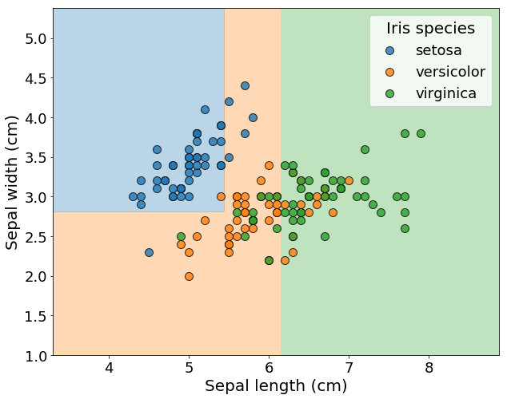

```python
plotting.plot_tree_decision_regions(clf)
```

# Model validation

## Model performance metrics

- There are many different performance metrics for classification and regression problems. Which metric you should use depends on the particular problem you are working on
- Many commonly used performance metrics are built into the `metrics` subpackage in scikit-learn
- Custom user-defined scoring function can be created using the `sklearn.metrics.make_scorer` function

```python
# Classification metrics
from sklearn.metrics import (accuracy_score, precision_score,
                             recall_score, f1_score, log_loss)
# Regression metrics
from sklearn.metrics import mean_squared_error, mean_absolute_error, r2_score
```

```python
y_true = [0, 1, 1, 3, 2]
y_pred = [0, 2, 1, 3, 1]
```

```python
accuracy_score(y_true, y_pred)
```

```
0.6
```

```python
mean_squared_error(y_true, y_pred)
```

```
0.4
```

## Separate training & testing sets

- A trained model will generally perform better on data that was used to train it
- Want to measure how well a model generalizes to new, unseen data
- Need to have two separate datasets. One for training models and one for evaluating model performance
- scikit-learn has a convenient `train_test_split` function that randomly splits a dataset into a testing and training set

```python
from sklearn.model_selection import train_test_split

X_train, X_test, y_train, y_test = train_test_split(X, y, test_size=0.2,
                                                    random_state=2)

print(f'X.shape = {X.shape}')
print(f'X_test.shape = {X_test.shape}')
print(f'X_train.shape = {X_train.shape}')
```

```
X.shape = (150, 2)
X_test.shape = (30, 2)
X_train.shape = (120, 2)
```

```python
clf = DecisionTreeClassifier()
clf.fit(X_train, y_train)
print(f'training accuracy = {accuracy_score(y_train, clf.predict(X_train))}')
print(f'testing accuracy = {accuracy_score(y_test, clf.predict(X_test))}')
```

```
training accuracy = 0.9333333333333333
testing accuracy = 0.7
```

## Model selection — hyperparameter optimization

- Choose model hyperparameter values to avoid under- and over-fitting
- Under-fitting — model isn't sufficiently complex enough to properly model the dataset at hand
- Over-fitting — model is too complex and begins to learn the noise in the training dataset

[figure not shown]

Image source: [Underfitting vs. Overfitting](http://scikit-learn.org/stable/auto_examples/model_selection/plot_underfitting_overfitting.html) in scikit-learn examples

## $k$-fold cross validation diagram

[figure not shown]

Image source: Raschka, Sebastian, and Vahid Mirjalili. [Python Machine Learning](https://www.amazon.com/Python-Machine-Learning-scikit-learn-TensorFlow/dp/1787125939), 2nd Ed. Packt Publishing, 2017.

## Cross validation in scikit-learn

```python
from sklearn.model_selection import cross_validate

clf = DecisionTreeClassifier(max_depth=2)
scores = cross_validate(clf, X_train, y_train,
                        scoring='accuracy', cv=10,
                        return_train_score=True)

print(scores.keys())
test_scores = scores['test_score']
train_scores = scores['train_score']
print(test_scores)
print(train_scores)

print('\n10-fold CV scores:')
print(f'training score = {np.mean(train_scores)} +/- {np.std(train_scores)}')
print(f'validation score = {np.mean(test_scores)} +/- {np.std(test_scores)}')
```

```
dict_keys(['fit_time', 'score_time', 'test_score', 'train_score'])
[0.84615385 0.76923077 0.75       0.58333333 0.91666667 0.66666667
 0.91666667 0.83333333 0.63636364 0.72727273]
[0.76635514 0.77570093 0.77777778 0.7962963  0.75925926 0.78703704
 0.75925926 0.76851852 0.78899083 0.74311927]

10-fold CV scores:
training score = 0.7722314314657621 +/- 0.015344020267747309
validation score = 0.7645687645687647 +/- 0.10869446623132276
```

## Validation curves

Validation curves are a good way to diagnose if a model is under- or over-fitting

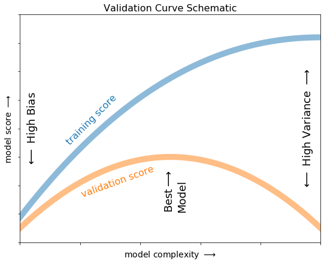

```python
plotting.plot_validation_curve()
```

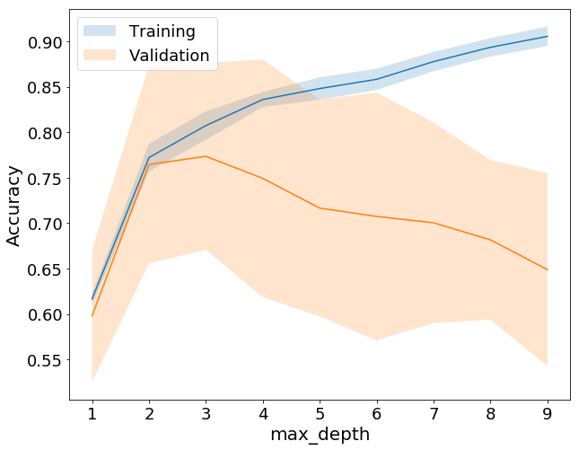

```python
plotting.plot_max_depth_validation(clf, X_train, y_train)
```

## Hyperparameter tuning via GridSearchCV

- In practice, you'll want to optimize many different hyperparameter values simultaneously
- The `GridSearchCV` object in scikit-learn's `model_selection` subpackage can be used to scan over many different hyperparameter combinations
- Calculates cross-validated training and testing scores for each hyperparameter combinations
- The combination that maximizes the testing score is deemed to be the "best estimator"

```python
from sklearn.model_selection import GridSearchCV

# Instantiate a model
clf = DecisionTreeClassifier()

# Specify hyperparameter values to test
parameters = {'max_depth': range(1, 20),
              'criterion': ['gini', 'entropy']}

# Run grid search
gridsearch = GridSearchCV(clf, parameters, scoring='accuracy', cv=10)
gridsearch.fit(X_train, y_train)

# Get best model
print(f'gridsearch.best_params_ = {gridsearch.best_params_}')
print(gridsearch.best_estimator_)
```

```
gridsearch.best_params_ = {'criterion': 'gini', 'max_depth': 3}
DecisionTreeClassifier(class_weight=None, criterion='gini', max_depth=3,
            max_features=None, max_leaf_nodes=None,
            min_impurity_decrease=0.0, min_impurity_split=None,
            min_samples_leaf=1, min_samples_split=2,
            min_weight_fraction_leaf=0.0, presort=False, random_state=None,
            splitter='best')
```

## Supervised machine learning workflow

[figure not shown]

Image source: [Model evaluation, model selection, and algorithm selection in machine learning](https://sebastianraschka.com/blog/2016/model-evaluation-selection-part3.html) by Sebastian Raschka

## Step 1 — Separate training and testing datasets

[figure not shown]

Image source: [Model evaluation, model selection, and algorithm selection in machine learning](https://sebastianraschka.com/blog/2016/model-evaluation-selection-part3.html) by Sebastian Raschka

```python
X_train, X_test, y_train, y_test = train_test_split(X, y, test_size=0.3,
                                                    random_state=2)
```

## Steps 2 & 3 — Optimize hyperparameters via cross validation

[figure not shown]

Image source: [Model evaluation, model selection, and algorithm selection in machine learning](https://sebastianraschka.com/blog/2016/model-evaluation-selection-part3.html) by Sebastian Raschka

```python
clf = DecisionTreeClassifier()
parameters = {'max_depth': range(1, 20),
              'criterion': ['gini', 'entropy']}
gridsearch = GridSearchCV(clf, parameters, scoring='accuracy', cv=10)
gridsearch.fit(X_train, y_train)
print(f'gridsearch.best_params_ = {gridsearch.best_params_}')

best_clf = gridsearch.best_estimator_
best_clf
```

```
gridsearch.best_params_ = {'criterion': 'gini', 'max_depth': 3}
```

```
DecisionTreeClassifier(class_weight=None, criterion='gini', max_depth=3,
            max_features=None, max_leaf_nodes=None,
            min_impurity_decrease=0.0, min_impurity_split=None,
            min_samples_leaf=1, min_samples_split=2,
            min_weight_fraction_leaf=0.0, presort=False, random_state=None,
            splitter='best')
```

## Steps 4 — Model performance

[figure not shown]

Image source: [Model evaluation, model selection, and algorithm selection in machine learning](https://sebastianraschka.com/blog/2016/model-evaluation-selection-part3.html) by Sebastian Raschka

```python
y_pred = best_clf.predict(X_test)
test_acc = accuracy_score(y_test, y_pred)
print(f'test_acc = {test_acc}')
```

```
test_acc = 0.8222222222222222
```

## Steps 5 — Train final model on full dataset

[figure not shown]

Image source: [Model evaluation, model selection, and algorithm selection in machine learning](https://sebastianraschka.com/blog/2016/model-evaluation-selection-part3.html) by Sebastian Raschka

```python
final_model = DecisionTreeClassifier(**gridsearch.best_params_)
final_model.fit(X, y)
```

```
DecisionTreeClassifier(class_weight=None, criterion='gini', max_depth=3,
            max_features=None, max_leaf_nodes=None,
            min_impurity_decrease=0.0, min_impurity_split=None,
            min_samples_leaf=1, min_samples_split=2,
            min_weight_fraction_leaf=0.0, presort=False, random_state=None,
            splitter='best')
```

## Iris classification problem

```python
# Step 1: Get training and testing datasets
X_train, X_test, y_train, y_test = train_test_split(X, y, test_size=0.3,
                                                    random_state=2)

# Step 2: Use GridSearchCV to find optimal hyperparameter values
clf = DecisionTreeClassifier(random_state=2)
parameters = {'max_depth': range(1, 20),
              'criterion': ['gini', 'entropy']}
gridsearch = GridSearchCV(clf, parameters, scoring='accuracy', cv=10)
gridsearch.fit(X_train, y_train)
print(f'gridsearch.best_params_ = {gridsearch.best_params_}')

# Step 3: Get model with best hyperparameters
best_clf = gridsearch.best_estimator_

# Step 4: Get best model performance from testing set
y_pred = best_clf.predict(X_test)
test_acc = accuracy_score(y_test, y_pred)
print(f'test_acc = {test_acc}')

# Step 5: Train final model on full dataset
final_model = DecisionTreeClassifier(random_state=2, **gridsearch.best_params_)
final_model.fit(X, y);
```

```
gridsearch.best_params_ = {'criterion': 'gini', 'max_depth': 3}
test_acc = 0.8222222222222222
```

## Additional Resources

- *Python Machine Learning* by Sebastian Raschka [[GitHub](https://github.com/rasbt/python-machine-learning-book-2nd-edition)][[Amazon](https://www.amazon.com/Python-Machine-Learning-scikit-learn-TensorFlow/dp/1787125939)]
- *Data Science Handbook* by Jake VanderPlas [[GitHub](https://github.com/jakevdp/PythonDataScienceHandbook)][[Amazon](https://www.amazon.com/_/dp/1491912057?tag=oreilly20-20)]
- *The Elements of Statistical Learning* by Hastie, Tibshirani and Friedman [[Free book!](https://web.stanford.edu/~hastie/ElemStatLearn/)]
- *Deep Learning* by Ian Goodfellow, Yoshua Bengio, and Aaron Courville [[Amazon](https://www.amazon.com/Deep-Learning-Adaptive-Computation-Machine/dp/0262035618)]